# RLab2

Nitiphong, Nirachornkul

9/06/2021

# Background

In this lab assignment, we will first conduct exploratory data analysis, then use multiple linear regression method to predict our variable of interest. Also, we will check the model assumptions, check for outliers and influential factors, and finally do predictions.

# Data Description

We have state level census data on various socio-economic and demographic data. The data consists of the following variables:

```r
names(StateData)
```

```
##  [1] "State"                       "OwnComputer"
##  [3] "CommutePublicTransport"      "TotalPopulation"
##  [5] "MedianAge"                   "WithCashAssistanceIncome"
##  [7] "MeanSocialSecurityIcnome"    "SupplementarySecurityIncome"
##  [9] "WhiteOnly"                   "Latinos"
## [11] "Asians"                      "AfricanAmerican"
## [13] "Income100K.150K"             "Income75K.100K"
## [15] "Income50K.75K"               "Income35K.50K"
## [17] "Income25K.35K"               "PovertyRate"
## [19] "X"                           "X.1"
## [21] "X.2"
```

```r
mydata <- as.matrix(StateData[,2:18])
```

There are 53 observations and 17 variables in the data. Some variables are presented in percentage points as a fraction of the total population. Below is a snapshot of our data.

```r
knitr::kable(head(StateData))
```

| State | OwnComputer | CommutePublicTransport | TotalPopulation | MedianAge | WithCashAssistanceIncome | MeanSocialSecurityIcnome | SupplementarySecurityIncome | WhiteOnly | Latinos | Asians | AfricanAmerican | Income100K.150K | Income75K.100K | Income50K.75K | Income35K.50K | Income25K.35K | PovertyRate | X | X.1 | X.2 |
| --- | --- | --- | --- | --- | --- | --- | --- | --- | --- | --- | --- | --- | --- | --- | --- | --- | --- | --- | --- | --- |
| Minnesota | 90.3 | 198984.888 | 5527358 | 37.9 | 3.4 | 20192 | 4.2 | 80.3 | 0.1 | 1.2 | 7.4 | 17.2 | 14.0 | 18.0 | 12.1 | 8.2 | 10.1 | NA | NA | NA |
| Mississippi | 81.5 | 8966.286 | 2988762 | 37.2 | 2.2 | 17667 | 7.9 | 56.8 | 0.1 | 1.2 | 38.4 | 10.4 | 11.2 | 16.9 | 14.1 | 11.4 | 20.8 | NA | NA | NA |
| Missouri | 87.3 | 85260.868 | 6090062 | 38.5 | 1.9 | 19054 | 5.5 | 79.6 | 0.1 | 2.5 | 12.8 | 13.0 | 12.5 | 18.6 | 14.4 | 10.6 | 14.2 | NA | NA | NA |
| Montana | 87.3 | 8333.856 | 1041732 | 39.8 | 2.2 | 18696 | 4.4 | 86.3 | 0.1 | 1.3 | 1.0 | 12.6 | 12.2 | 19.1 | 14.4 | 11.1 | 13.7 | NA | NA | NA |
| Nebraska | 88.5 | 13333.320 | 1904760 | 36.4 | 1.9 | 19673 | 3.9 | 79.4 | 0.3 | 2.9 | 5.9 | 15.1 | 13.7 | 19.3 | 13.8 | 9.8 | 11.6 | NA | NA | NA |
| Nevada | 91.2 | 99376.866 | 2922849 | 37.9 | 3.0 | 19141 | 4.1 | 49.9 | 1.0 | 10.1 | 10.6 | 14.1 | 13.4 | 19.1 | 14.1 | 10.1 | 13.7 | NA | NA | NA |

Our target variable is **OwnComputer**, the percentage of people who own a computer. It may not be an interesting question, yet, in this lab assignment, we will try to find the factors that determine our target variable.

# Questions 1: Exploratory Data Analysis [15 points]

As a part of EDA, we will visually look at the relationship between our target variable *OwnComputer* and some other potential factors.

1.1 Use R to calculate the pairwise Pearson correlation coefficient between *OwnComputer* and all other state characteristics to identify the 3 variables that have the highest (in absolute value) correlation coefficient with *OwnComputer*.

```
## [1] 159
```

```
## [1] "According to the correlation matrix table, the highest three correlation are SupplementarySecurityIncome, Income25K.35K and Income100K.150K"
```

```
##                             OwnComputer CommutePublicTransport TotalPopulation
## OwnComputer                        1.00                   0.10            0.12
## CommutePublicTransport             0.10                   1.00            0.56
## TotalPopulation                    0.12                   0.56            1.00
## MedianAge                         -0.21                   0.05            0.08
## WithCashAssistanceIncome           0.30                   0.11           -0.04
## MeanSocialSecurityIcnome           0.24                   0.09            0.14
## SupplementarySecurityIncome       -0.65                   0.14            0.18
## WhiteOnly                         -0.15                  -0.16           -0.23
## Latinos                            0.10                   0.07            0.31
## Asians                             0.27                   0.18            0.14
## AfricanAmerican                   -0.30                   0.09            0.14
## Income100K.150K                    0.58                   0.16            0.03
## Income75K.100K                     0.33                  -0.07           -0.11
## Income50K.75K                     -0.08                  -0.12            0.02
## Income35K.50K                     -0.51                  -0.18            0.02
## Income25K.35K                     -0.65                  -0.17            0.01
## PovertyRate                       -0.33                  -0.02            0.06
##                             MedianAge WithCashAssistanceIncome
## OwnComputer                     -0.21                     0.30
## CommutePublicTransport           0.05                     0.11
## TotalPopulation                  0.08                    -0.04
## MedianAge                        1.00                     0.30
## WithCashAssistanceIncome         0.30                     1.00
## MeanSocialSecurityIcnome         0.84                     0.00
## SupplementarySecurityIncome      0.54                    -0.09
## WhiteOnly                        0.48                    -0.24
## Latinos                          0.12                    -0.02
## Asians                           0.06                     0.12
## AfricanAmerican                  0.10                    -0.08
## Income100K.150K                 -0.20                    -0.16
## Income75K.100K                  -0.19                    -0.46
## Income50K.75K                    0.71                    -0.11
## Income35K.50K                    0.70                    -0.05
## Income25K.35K                    0.67                     0.09
## PovertyRate                      0.36                     0.53
##                             MeanSocialSecurityIcnome
## OwnComputer                                     0.24
## CommutePublicTransport                          0.09
## TotalPopulation                                 0.14
```

[output cut: 327 more lines]

```
## TotalPopulation             0.9319        0.6494
## MedianAge                   0.0000        0.0082
## WithCashAssistanceIncome    0.5451        0.0000
## MeanSocialSecurityIcnome    0.0001        0.9802
## SupplementarySecurityIncome 0.0004        0.3732
## WhiteOnly                   0.0029        0.0440
## Latinos                     0.5773        0.7447
## Asians                      0.0316        0.2018
## AfricanAmerican             0.4234        0.0213
## Income100K.150K             0.0000        0.0000
## Income75K.100K              0.0015        0.0000
## Income50K.75K               0.0000        0.9419
## Income35K.50K               0.0000        0.0038
## Income25K.35K                             0.0000
## PovertyRate                 0.0000
```

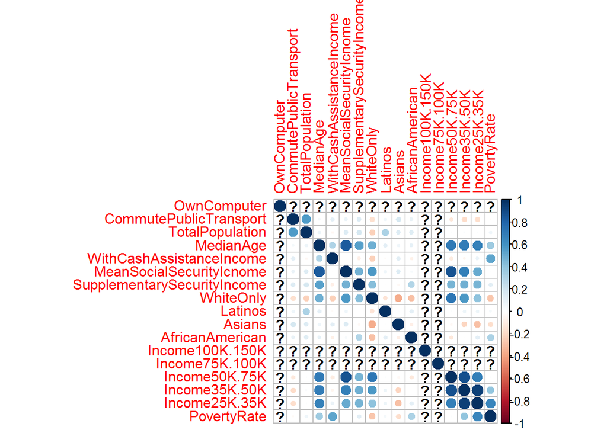

1.2 Then, use a scatter plot to describe the relationship between *OwnComputer* and each of those three variables. Describe the general trend. Include plots and R-code used.

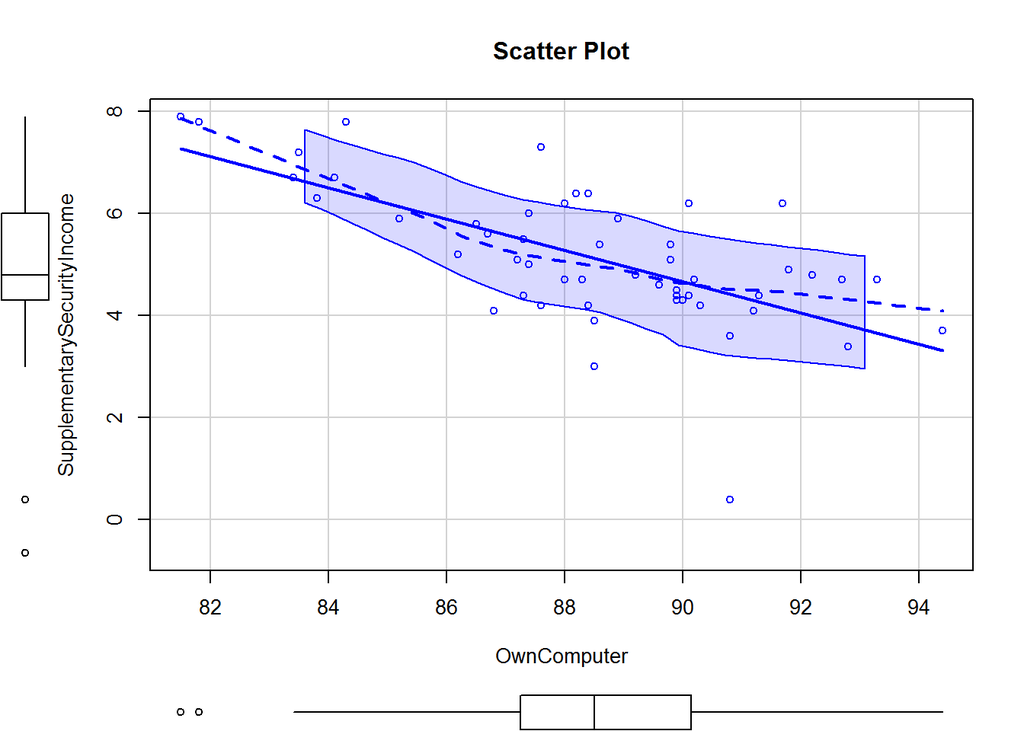

```
## [1] "The correlation between SupplementarySecurityIncome and OwnComputer is negative correlation as 65%"
```

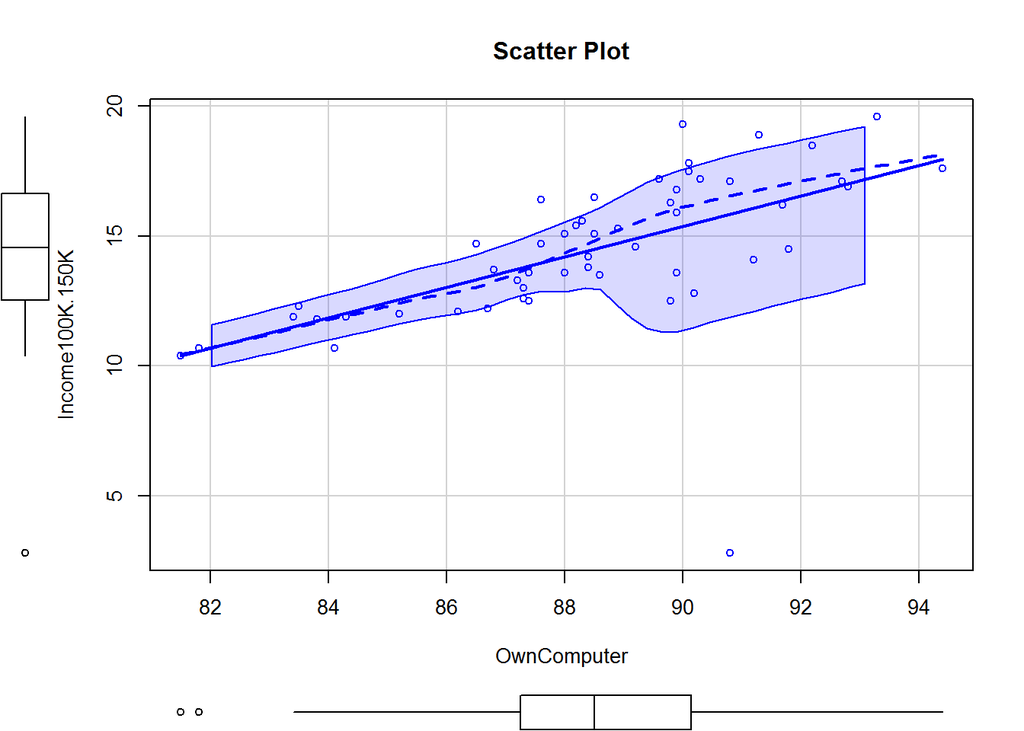

[output not shown]

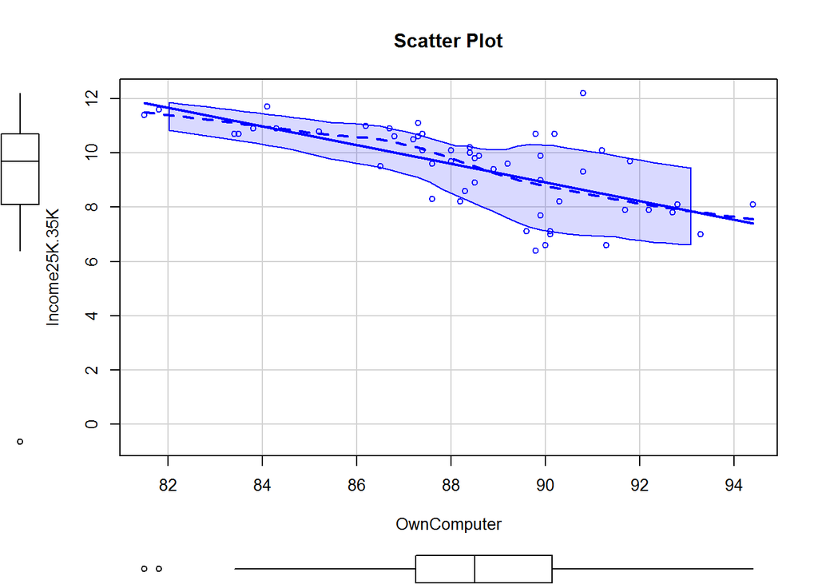

[output not shown]

# Questions 2: Model Fitting [35 points]

Now, we will start with a parsimonious model for *OwnComputer*.

2.1 Build a multiple linear regression model, called model1, shown below.${model1:~~~~~} OwnComputer = \beta_{0}+\beta_{1}Asians+\beta_{2}{PovertyRate} +\beta_{3}Income100K.150K +\epsilon$. Write an R code below to use mydata to estimate model1. Display the summary of model1.

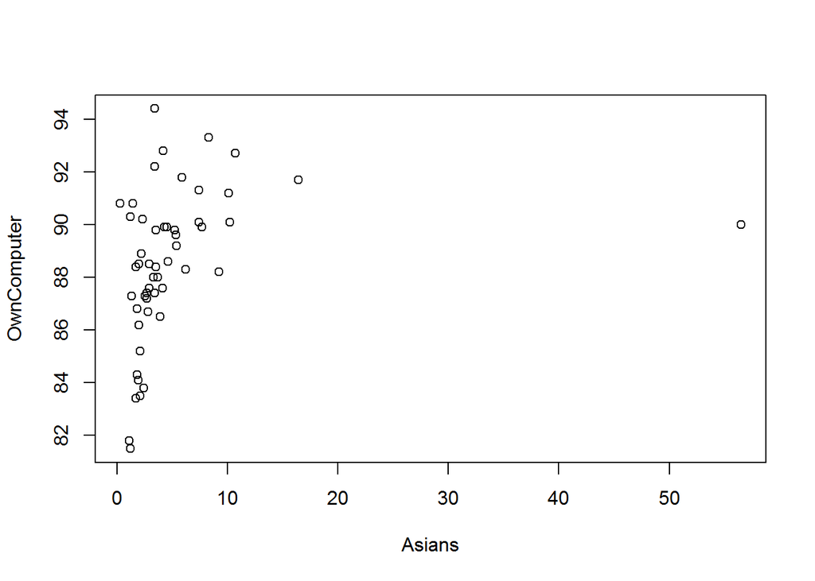

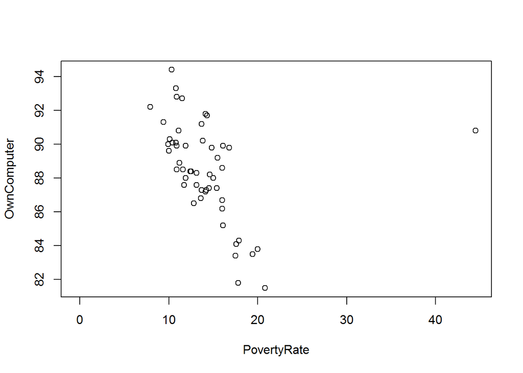

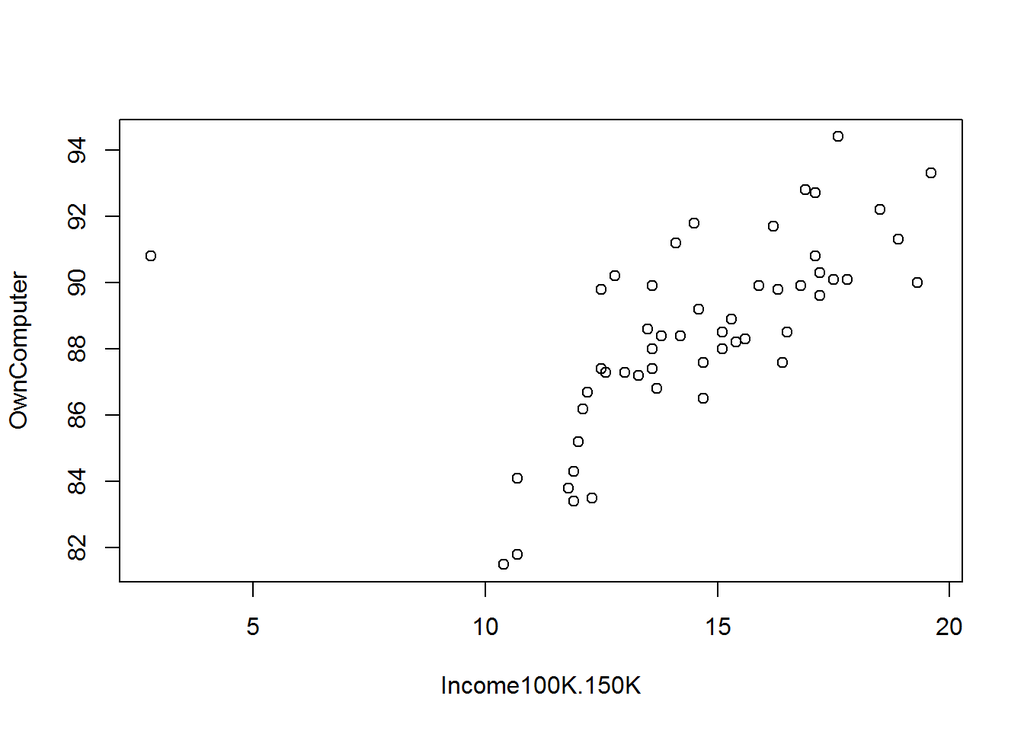

```
##
## Call:
## lm(formula = OwnComputer ~ Asians + PovertyRate + Income100K.150K,
##     data = StateData)
##
## Residuals:
##     Min      1Q  Median      3Q     Max
## -4.6545 -1.0858 -0.0344  1.0583  4.3388
##
## Coefficients:
##                 Estimate Std. Error t value Pr(>|t|)
## (Intercept)     64.17600    4.92178  13.039  < 2e-16 ***
## Asians          -0.03232    0.04379  -0.738   0.4641
## PovertyRate      0.42075    0.12223   3.442   0.0012 **
## Income100K.150K  1.27555    0.23524   5.422 1.89e-06 ***
## ---
## Signif. codes:  0 '***' 0.001 '**' 0.01 '*' 0.05 '.' 0.1 ' ' 1
##
## Residual standard error: 2.146 on 48 degrees of freedom
##   (1 observation deleted due to missingness)
## Multiple R-squared:  0.4721, Adjusted R-squared:  0.4391
## F-statistic: 14.31 on 3 and 48 DF,  p-value: 8.663e-07
```

```
##                      2.5 %      97.5 %
## (Intercept)     54.2800961 74.07190983
## Asians          -0.1203724  0.05572714
## PovertyRate      0.1749964  0.66650298
## Income100K.150K  0.8025738  1.74852660
```

Coefficient of PovertyRate is 0.42075.

3. Now, we will check for an outlier in the model. Write an R command below to create a plot for the Cook’s Distances.

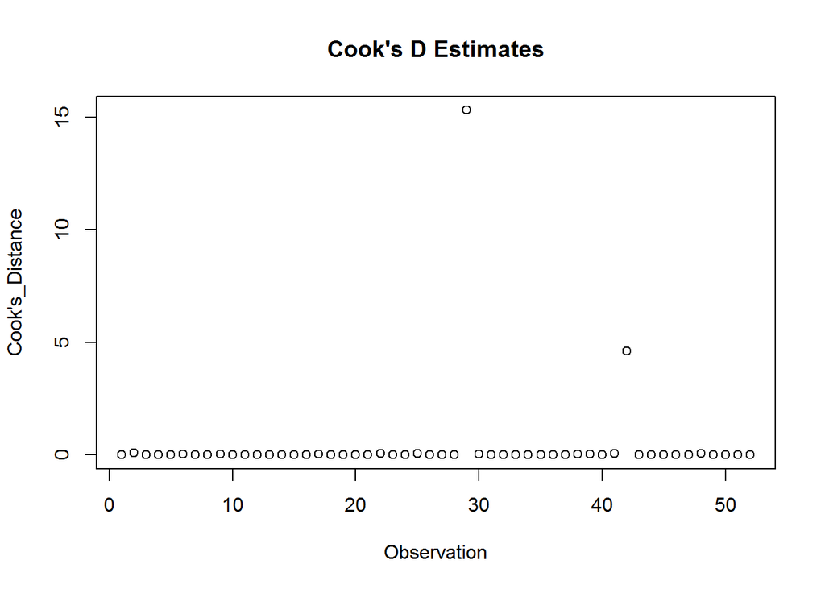

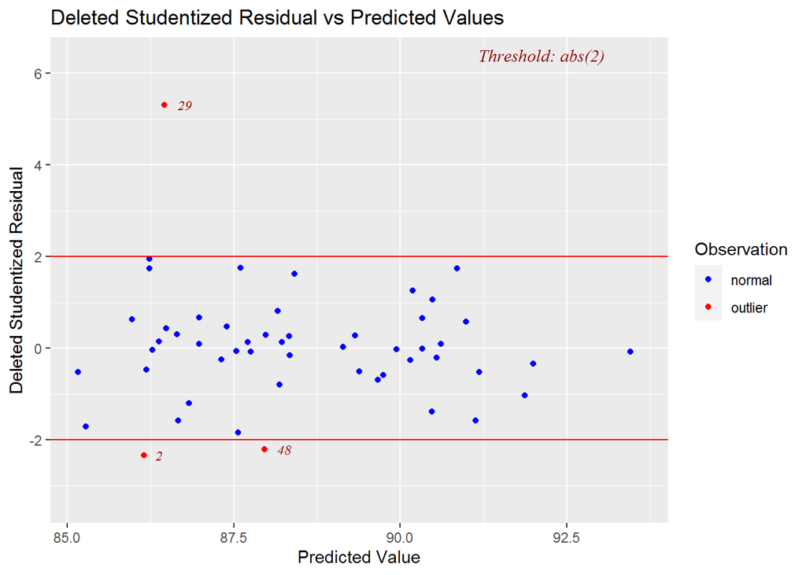

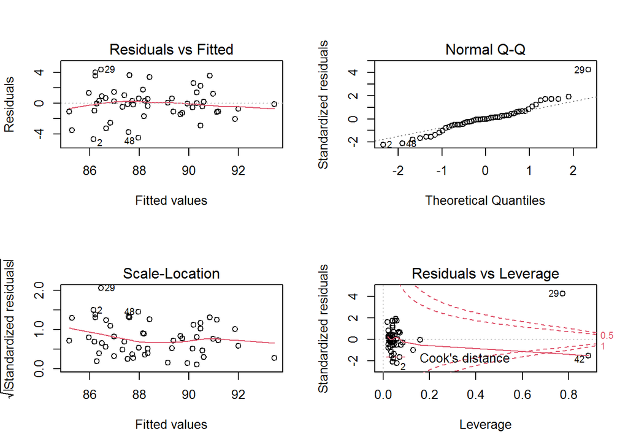

4. Now, we will remove the outlier(s) from the data set mydata and name the new dataset as *mydata1a*. Then, we will create a new model, called model1a, using all predictors we had in model1 with OwnComputer as the dependent variable. Write an R code below to use mydata1a to estimate model1a. Display the summary of model1a.

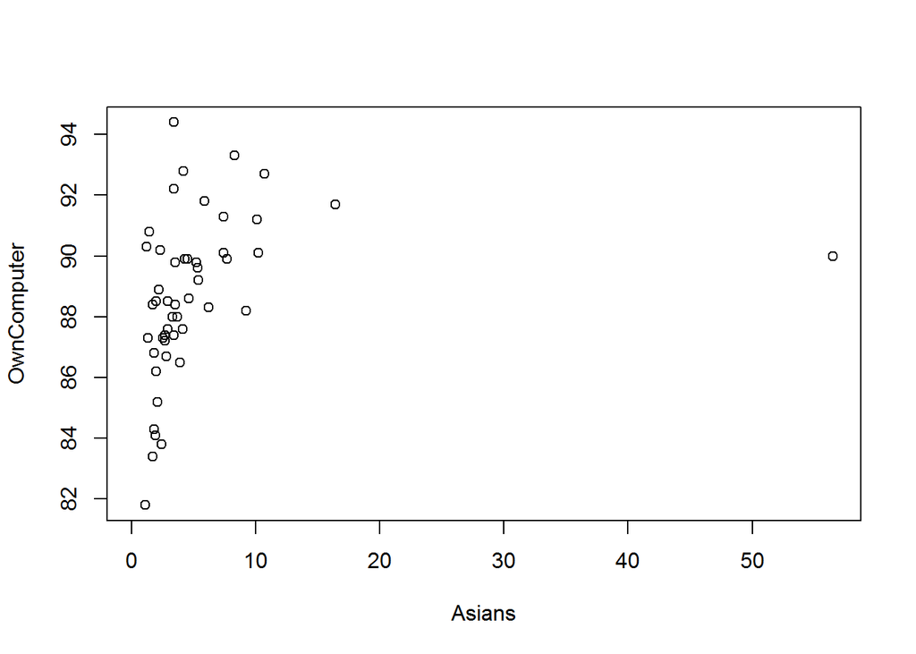

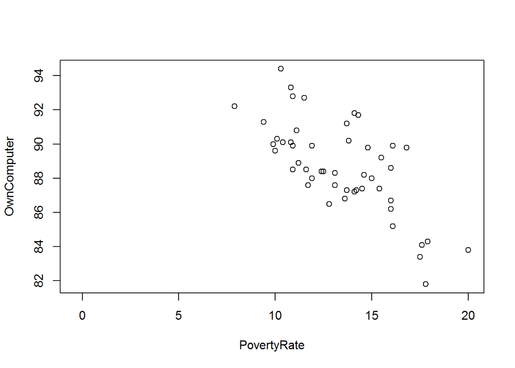

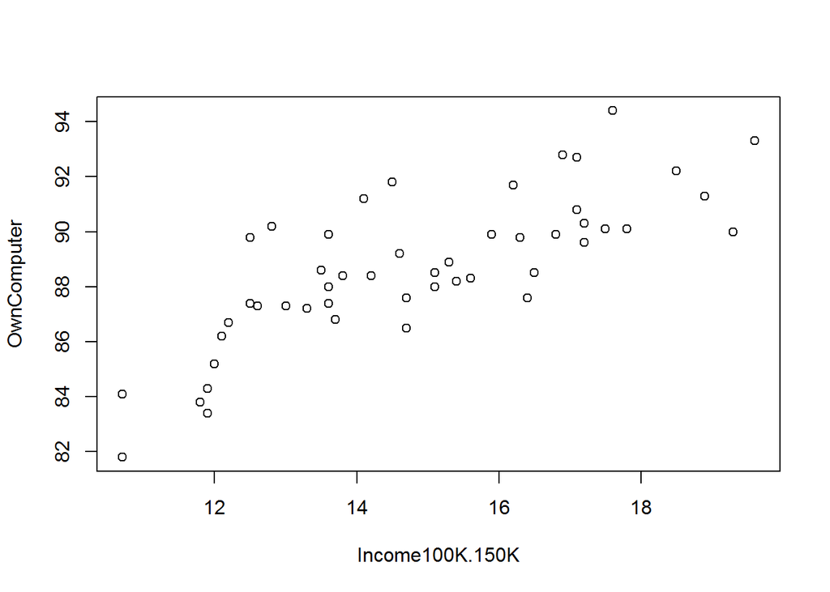

```
##
## Call:
## lm(formula = OwnComputer ~ Asians + PovertyRate + Income100K.150K,
##     data = mydata1a)
##
## Residuals:
##     Min      1Q  Median      3Q     Max
## -3.0631 -1.1102 -0.1996  0.5517  3.5120
##
## Coefficients:
##                 Estimate Std. Error t value Pr(>|t|)
## (Intercept)     78.88311    5.30492  14.870  < 2e-16 ***
## Asians          -0.02419    0.03464  -0.698 0.488615
## PovertyRate     -0.14047    0.17548  -0.801 0.427626
## Income100K.150K  0.79505    0.21767   3.653 0.000675 ***
## ---
## Signif. codes:  0 '***' 0.001 '**' 0.01 '*' 0.05 '.' 0.1 ' ' 1
##
## Residual standard error: 1.691 on 45 degrees of freedom
##   (1 observation deleted due to missingness)
## Multiple R-squared:  0.6192, Adjusted R-squared:  0.5938
## F-statistic: 24.39 on 3 and 45 DF,  p-value: 1.594e-09
```

```
##                       2.5 %      97.5 %
## (Intercept)     68.19845923 89.56776842
## Asians          -0.09396051  0.04558354
## PovertyRate     -0.49391552  0.21296645
## Income100K.150K  0.35664934  1.23345695
```

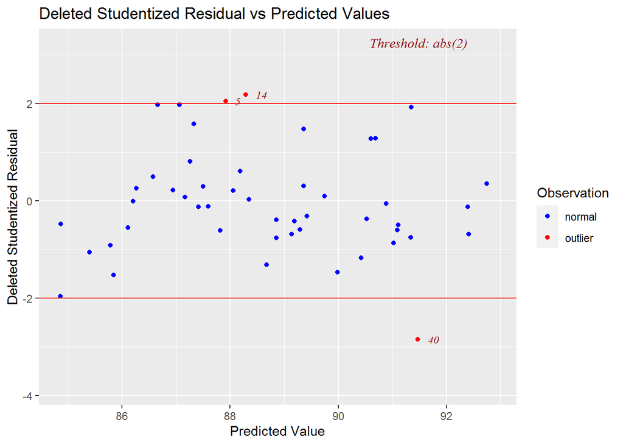

1. Comment on the performance of model1 and model1a: Which model does a better job in terms of Adjusted R-square value?  
   The model1a has better Adjusted R-square value as 0.5938 than model1 as 0.4391.
5. Now, we will build a greater model by adding *Income25K.35K*, *SupplementarySecurityIncome*, and *WhiteOnly* and call it *model2*. The regression equation is shown below.

${model2:}~~~ OwnComputer=\beta_{0}+\beta_{1}Asians+\beta_{2}{PovertyRate}+\beta_{3}Income100K.150K\\ +\beta_{4}Income25K.35K+\beta_{5}SupplementarySecurityIncome+\beta_{6}WhiteOnly+\epsilon$

Write an R code below to use mydata1a (the one with outliers removed) to estimate model2. Display the summary of model2.

```
##
## Call:
## lm(formula = OwnComputer ~ Asians + PovertyRate + Income100K.150K +
##     Income25K.35K + SupplementarySecurityIncome + WhiteOnly,
##     data = mydata1a)
##
## Residuals:
##     Min      1Q  Median      3Q     Max
## -2.6624 -1.1840 -0.1870  0.6444  3.5433
##
## Coefficients:
##                             Estimate Std. Error t value Pr(>|t|)
## (Intercept)                 81.63722   14.51282   5.625 1.37e-06 ***
## Asians                      -0.05645    0.04331  -1.303   0.1995
## PovertyRate                 -0.14276    0.29097  -0.491   0.6262
## Income100K.150K              0.81834    0.48905   1.673   0.1017
## Income25K.35K                0.27821    0.62823   0.443   0.6601
## SupplementarySecurityIncome -0.59575    0.33415  -1.783   0.0818 .
## WhiteOnly                   -0.03526    0.03099  -1.138   0.2616
## ---
## Signif. codes:  0 '***' 0.001 '**' 0.01 '*' 0.05 '.' 0.1 ' ' 1
##
## Residual standard error: 1.554 on 42 degrees of freedom
##   (1 observation deleted due to missingness)
## Multiple R-squared:  0.6996, Adjusted R-squared:  0.6567
## F-statistic:  16.3 on 6 and 42 DF,  p-value: 1.387e-09
```

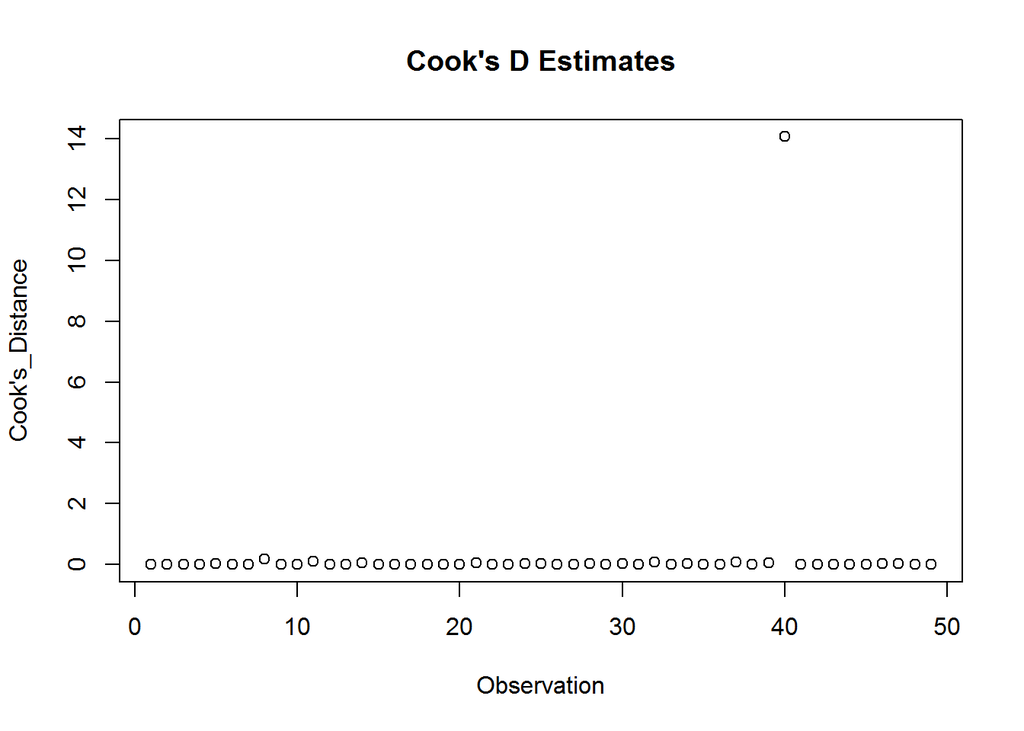

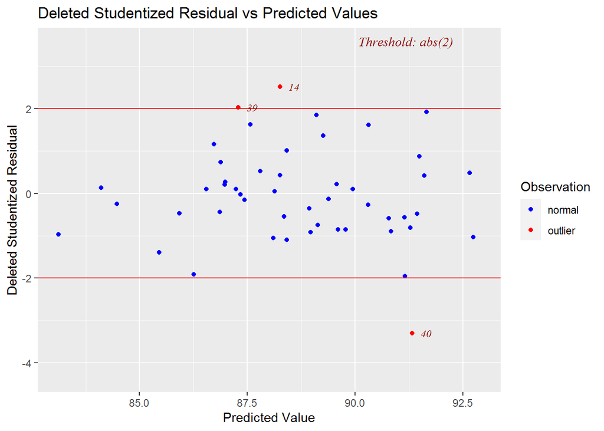

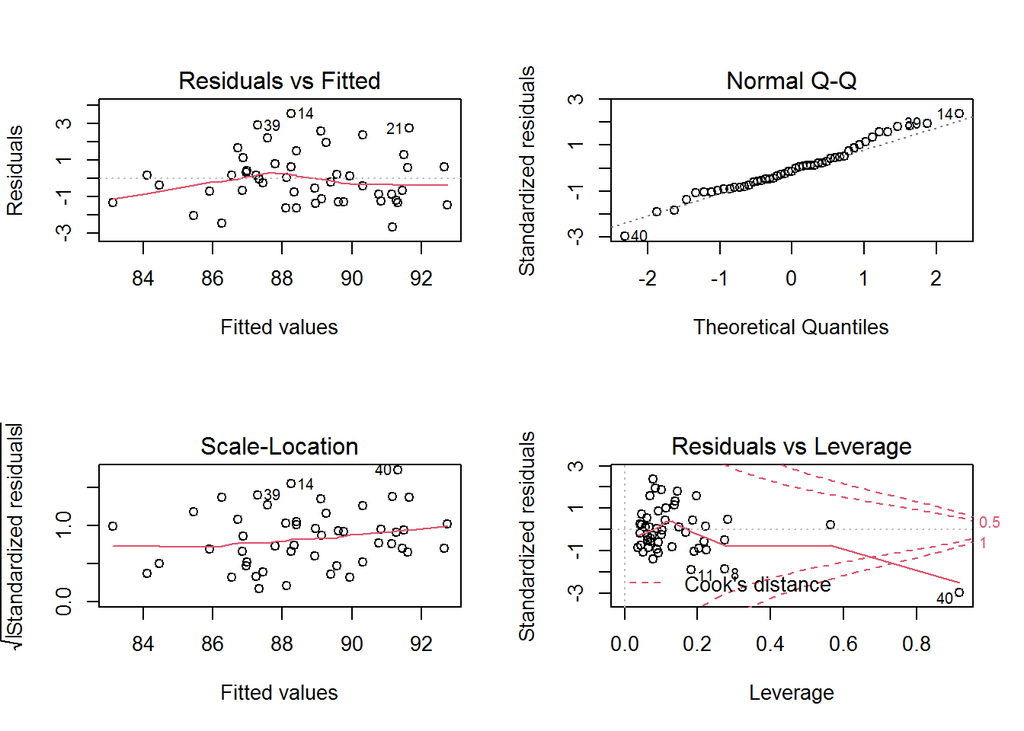

# Questions 3: Checking Model Assumptions [30 points]

So far, we built three models: model1, model1a and model2. You will see that our largest model (model2) has the highest Adjusted-R squared value. Hence, we will test the model assumptions on model2.

```
##
## Call:
## lm(formula = OwnComputer ~ Asians + PovertyRate + Income100K.150K,
##     data = StateData)
##
## Residuals:
##     Min      1Q  Median      3Q     Max
## -4.6545 -1.0858 -0.0344  1.0583  4.3388
##
## Coefficients:
##                 Estimate Std. Error t value Pr(>|t|)
## (Intercept)     64.17600    4.92178  13.039  < 2e-16 ***
## Asians          -0.03232    0.04379  -0.738   0.4641
## PovertyRate      0.42075    0.12223   3.442   0.0012 **
## Income100K.150K  1.27555    0.23524   5.422 1.89e-06 ***
## ---
## Signif. codes:  0 '***' 0.001 '**' 0.01 '*' 0.05 '.' 0.1 ' ' 1
##
## Residual standard error: 2.146 on 48 degrees of freedom
##   (1 observation deleted due to missingness)
## Multiple R-squared:  0.4721, Adjusted R-squared:  0.4391
## F-statistic: 14.31 on 3 and 48 DF,  p-value: 8.663e-07
```

```
##
## Call:
## lm(formula = OwnComputer ~ Asians + PovertyRate + Income100K.150K,
##     data = mydata1a)
##
## Residuals:
##     Min      1Q  Median      3Q     Max
## -3.0631 -1.1102 -0.1996  0.5517  3.5120
##
## Coefficients:
##                 Estimate Std. Error t value Pr(>|t|)
## (Intercept)     78.88311    5.30492  14.870  < 2e-16 ***
## Asians          -0.02419    0.03464  -0.698 0.488615
## PovertyRate     -0.14047    0.17548  -0.801 0.427626
## Income100K.150K  0.79505    0.21767   3.653 0.000675 ***
## ---
## Signif. codes:  0 '***' 0.001 '**' 0.01 '*' 0.05 '.' 0.1 ' ' 1
##
## Residual standard error: 1.691 on 45 degrees of freedom
##   (1 observation deleted due to missingness)
## Multiple R-squared:  0.6192, Adjusted R-squared:  0.5938
## F-statistic: 24.39 on 3 and 45 DF,  p-value: 1.594e-09
```

```
##
## Call:
## lm(formula = OwnComputer ~ Asians + PovertyRate + Income100K.150K +
##     Income25K.35K + SupplementarySecurityIncome + WhiteOnly,
##     data = mydata1a)
##
## Residuals:
##     Min      1Q  Median      3Q     Max
## -2.6624 -1.1840 -0.1870  0.6444  3.5433
##
## Coefficients:
##                             Estimate Std. Error t value Pr(>|t|)
## (Intercept)                 81.63722   14.51282   5.625 1.37e-06 ***
## Asians                      -0.05645    0.04331  -1.303   0.1995
## PovertyRate                 -0.14276    0.29097  -0.491   0.6262
## Income100K.150K              0.81834    0.48905   1.673   0.1017
## Income25K.35K                0.27821    0.62823   0.443   0.6601
## SupplementarySecurityIncome -0.59575    0.33415  -1.783   0.0818 .
## WhiteOnly                   -0.03526    0.03099  -1.138   0.2616
## ---
## Signif. codes:  0 '***' 0.001 '**' 0.01 '*' 0.05 '.' 0.1 ' ' 1
##
## Residual standard error: 1.554 on 42 degrees of freedom
##   (1 observation deleted due to missingness)
## Multiple R-squared:  0.6996, Adjusted R-squared:  0.6567
## F-statistic:  16.3 on 6 and 42 DF,  p-value: 1.387e-09
```

6. We will first create a scatterplot of the standardized residuals of model2 against each feature (predictor) in our model. This is also called component residual plot or partial residual plot. crPlots function in R can be handy to create the partial residual plots.

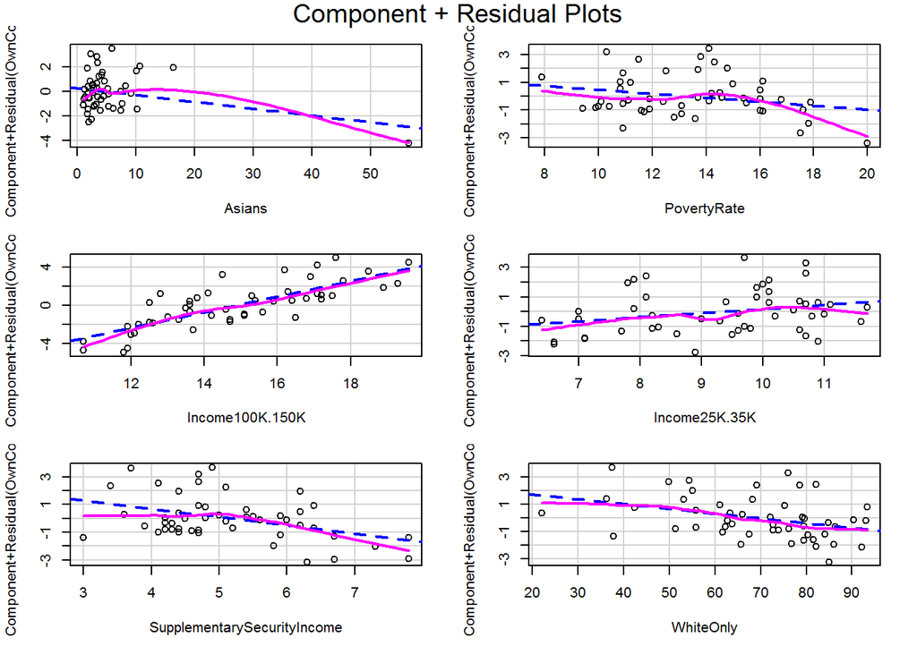

Based on the results, does the linearity assumption hold? the results are not the linearity assumption hold except income100K.150K.

7. Now, we will create a scatterplot of the standardized residuals of model2 against the fitted values of model2 to check if the constant variance assumption holds or not?

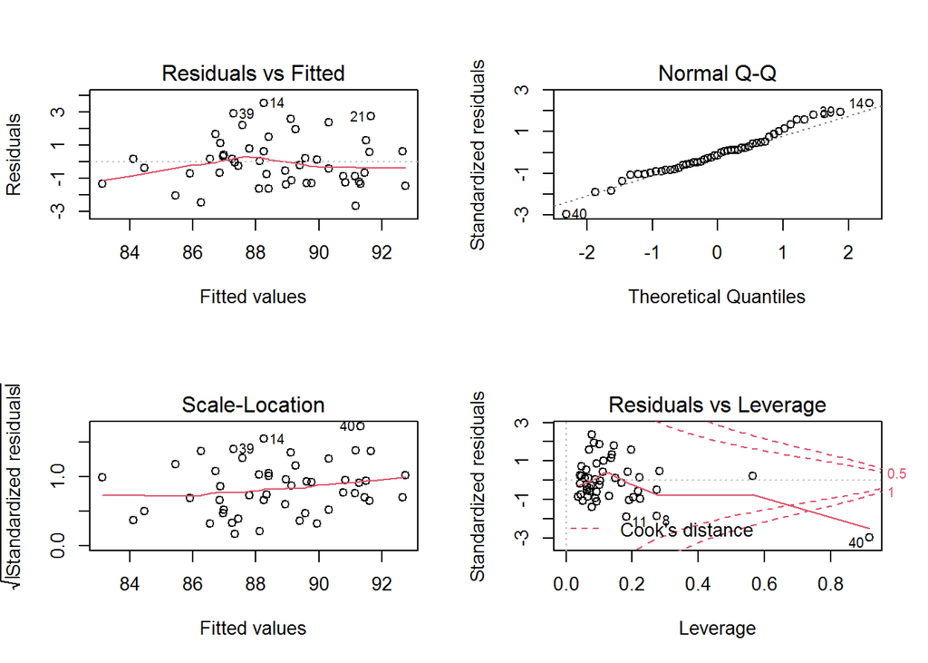

From the Scale-Location Plot, it is not a horizontal line with equally spread points, it has trend, so the error terms is not constant variance.

Do the errors appear uncorrelated? yes

8. This time, we will check the normality assumption with the help of histogram and normal QQ plot for the standardized residuals. Does the normality assumption hold?

The model2 is right skewness.

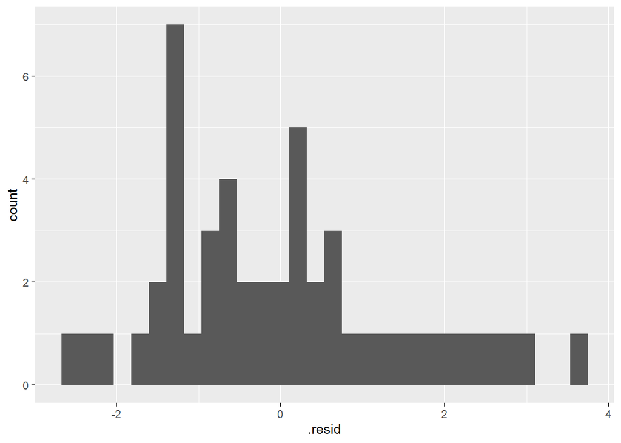

9. Finally, we will check for multicollinearity by calculating the variance inflation factor (VIF). Calculate VIF for each predictor in model2.

Any VIF value above 10 can be considered as an evidence of multicollinearity. What conclusions you can draw from the results.

```
##                     Variables  Tolerance       VIF
## 1                      Asians 0.41328187  2.419656
## 2                 PovertyRate 0.08370131 11.947245
## 3             Income100K.150K 0.03945704 25.344017
## 4               Income25K.35K 0.05914860 16.906571
## 5 SupplementarySecurityIncome 0.37072612  2.697409
## 6                   WhiteOnly 0.19609400  5.099595
```

The results of variance Inflation Factor(VIF) shows the significant factors are PovertyRate as 11.947245, Income100K.150K as 25.344017, and Income25K.35K as 16.906571 that their VIF are higher than 10.

10. Now, we will build a new model and call it model3 by dropping all predictors from model2 with VIF value above 10. Write an R code below to update model2 by removing predictors with signs of multicollinearity (VIF>10). Display the summary of model3.

```
##
## Call:
## lm(formula = OwnComputer ~ Asians + SupplementarySecurityIncome +
##     WhiteOnly, data = mydata1a)
##
## Residuals:
##     Min      1Q  Median      3Q     Max
## -3.3649 -1.4648  0.0679  1.1825  3.8420
##
## Coefficients:
##                             Estimate Std. Error t value Pr(>|t|)
## (Intercept)                 96.55618    2.28898  42.183  < 2e-16 ***
## Asians                       0.05025    0.04646   1.082    0.285
## SupplementarySecurityIncome -1.44806    0.27330  -5.298 3.39e-06 ***
## WhiteOnly                   -0.01032    0.02274  -0.454    0.652
## ---
## Signif. codes:  0 '***' 0.001 '**' 0.01 '*' 0.05 '.' 0.1 ' ' 1
##
## Residual standard error: 2.07 on 45 degrees of freedom
##   (1 observation deleted due to missingness)
## Multiple R-squared:  0.4292, Adjusted R-squared:  0.3912
## F-statistic: 11.28 on 3 and 45 DF,  p-value: 1.215e-05
```

[output not shown]

# Questions 4: Model Comparison [5 points]

11. So far, we have created four models: model1, model1a, model2 and model3. Model2 is the largest model. Based on Adjusted-R squared value which model performs best?

    ```
    Adjusted R-squared
    ```

    model1 0.4391 model1a 0.5938 model2 0.6567 model3 0.3912

The model2 has the highest R-squared which mean that has the best R-squared. The second highest R-squared is model1a. The third highest R-squared is model1. finally, the last one is model3.

We can conduct partial F test to see if a larger model makes sense, but, we will skip it for now.

# Questions 5: Prediction [10 points]

12. Imagine the following scenario: Canada made a referendum to join the US as the 51st state.  
    The US happily accepted them as the 51st state. Use model1, model1a, model2 and model3 to predict the *OwnComputer* ratio in Canada with a 90% prediction interval. Provide an interpretation of your findings.

Which model has a narrower band? Is there any relationship between the prediction band width and the Adjusted-R squared values?

Hypothetical Data for Canada:

Asians: 18.4  
PovertyRate: 5.8  
Income100K.150K: 23  
Income25K.35K: 13  
SupplementarySecurityIncome: 9  
WhiteOnly: 75

```
##                             [,1]
## Asians                      18.4
## PovertyRate                  5.8
## Income100K.150K             23.0
## Income25K.35K               13.0
## SupplementarySecurityIncome  9.0
## WhiteOnly                   75.0
```

```
##        fit      lwr      upr
## 1 95.35927 91.31801 99.40053
```

```
##        fit      lwr      upr
## 1 95.90952 92.69624 99.12279
```

```
##        fit      lwr      upr
## 1 94.20269 83.42803 104.9774
```

```
##        fit      lwr      upr
## 1 83.67414 79.51599 87.83229
```